# Russia and NATO Enlargement

Did the 2002 Prague Summit Increase Russian Aggression Toward the Baltic States?

Aliana Sheriff

alianasheriff@icloud.com

**Note**

This presentation summarizes the findings of a quantitative research paper examining whether NATO’s 2002 Prague Summit invitation to the Baltic states triggered escalatory behavior from Russia.

Using GDELT event data (2000–2008) and a difference-in-differences design, the paper compares Russia’s verbal and material conflict toward Estonia, Latvia, and Lithuania against a control group of longstanding NATO members and a placebo group of non-Baltic 2004 entrants.

Please see the accompanying paper for the complete analysis, regression tables, and robustness checks.

# Motivation

## Motivation

### Introduction

- In November 2002, NATO’s **Prague Summit** invited seven countries to join the alliance
- Among them: **Estonia, Latvia, and Lithuania**, former Soviet republics on Russia’s border
- This brought NATO **directly to Russia’s frontier** for the first time

## Motivation

**Main question:**

Did Russia react differently to Baltic enlargement than to other 2004 NATO entrants, and if so, how?

## Motivation

### Why the Baltics Are Different

Three factors made Baltic accession uniquely sensitive from Moscow’s perspective:

**1. Imperial history** The Baltics were former Soviet republics and losing them to NATO was not just geopolitical, but a symbolic confirmation that Russia’s imperial sphere was gone

**2. Russian-speaking minorities** Estonia and Latvia had large Russian-speaking populations (~25–30%) facing restrictive citizenship laws. Moscow claimed a responsibility to protect them

## Motivation

### Why the Baltics Are Different Continued

**3. Geographic proximity** Tallinn is less than 200 miles from St. Petersburg; Lithuania borders Kaliningrad, home to Russia’s Baltic Fleet

## Motivation

### The Study Region

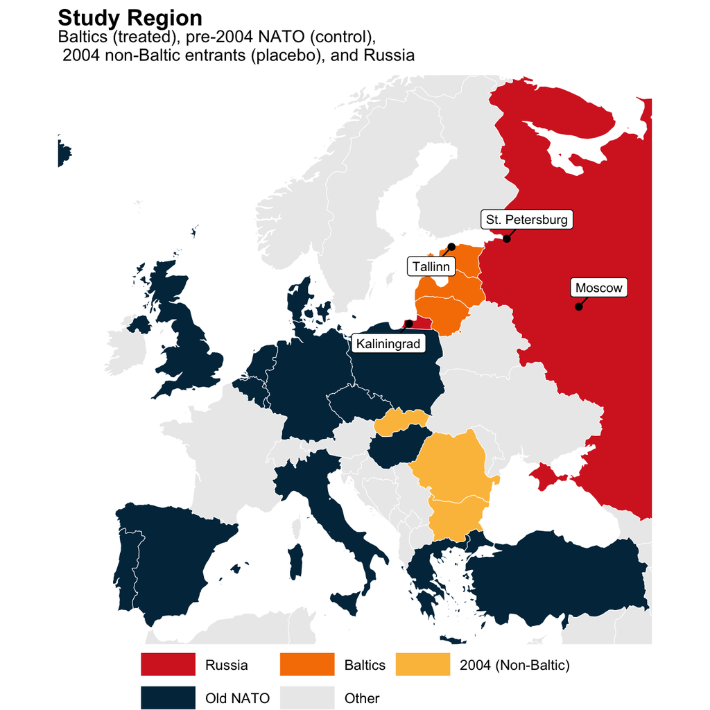

## Table of Contents

1. Literature Review
2. Theoretical Framework & Hypotheses
3. Data & Methodology
4. Findings
5. Discussion & Conclusion

# Literature Review

## Literature Review

### NATO Expansion and Security Competition

- **Mearsheimer (2014):** NATO expansion significantly threatened Russia’s sphere of influence and was predictable backlash from ignoring great power politics
- **Sarotte (2021):** Enlargement was not inevitable, but it emerged through contingent diplomatic decisions; Bush’s 1990 promise not to expand eastward was never honored
- **Asmus (2002):** Expansion was a deliberate effort to remake NATO for the post–Cold War era

## Literature Review

**Key tension:** Was Russia’s reaction structural insecurity, or perceived diplomatic betrayal?

## Literature Review

### The Baltic Case & Signaling Theory

**Baltic-specific factors:**

- Kramer (2002): Baltic enlargement posed unique challenges due to Russia’s security concerns and the region’s symbolic importance
- Trenin (2002): Russian foreign policy cannot be understood in purely material terms: civilizational identity matters
- Cheskin & Kachuyevski (2019): Russian-speaking minorities served as focal points for transnational protection narratives

## Literature Review

### The Baltic Case & Signaling Theory

**Signaling & Deterrence:**

- Schelling (1966): States use threats and limited actions to signal dissatisfaction without triggering uncontrolled escalation
- Fearon (1997): “Tying hands” vs. “sinking costs” as mechanisms for credible signaling
- Leeds (2003): Military alliances significantly reduce the likelihood of aggression against member states because of **Article 5 as deterrent**

# Theory & Hypotheses

## Theory & Hypotheses

Three competing expectations from the literature:

**H1 — Rhetorical Escalation** If NATO enlargement provoked Russia into signaling dissatisfaction, we should observe a measurable *increase* in the share and volume of verbal conflict directed toward the Baltic states following the 2002 Prague Summit.

**H2 — Material Restraint** If NATO’s Article 5 deters direct military confrontation, *material conflict* toward the Baltic states should remain stable even if rhetorical tensions rise.

## Theory & Hypotheses Continued

**H3 — Relational Withdrawal** If Russia disengaged entirely rather than escalating, we should observe a *broad decline* across all interaction types, reflecting a cooling of the relationship rather than targeted hostility.

# Data & Methodology

## Data & Methodology

### GDELT Event Data

- **Source:** Global Database of Events, Language and Tone (GDELT 1.0)
- **Unit:** Country-month observations: Russia as actor, 34 target countries
- **Period:** January 2000 – December 2008 (108 months, balanced panel)
- **Outcomes:** Event counts (verbal conflict, material conflict, cooperation) and *shares* (each type as proportion of total interactions)

| Group | Countries | Role |
| --- | --- | --- |
| Baltics | Estonia, Latvia, Lithuania | **Treated** |
| Old NATO | US, UK, France, Germany… | **Control** |
| Non-Baltic 2004 | Romania, Bulgaria, Slovakia | **Placebo** |

## Data & Methodology

### Difference-in-Differences Design

$$Y_{it} = \alpha + \beta(\text{Baltic}_{i} \times \text{Post2002}_{t}) + \gamma_{i} + \delta_{t} + \varepsilon_{it}$$

- $Y_{it}$ — Russia’s behavior toward country $i$ in month $t$ (verbal share or conflict count)
- $\beta$ — key coefficient: differential change in Baltic states after Prague Summit vs. control group
- $\gamma_{i}$ — country fixed effects (absorb time-invariant differences)
- $\delta_{t}$ — year-month fixed effects (absorb global temporal shocks)
- Standard errors clustered at the country level

## Data & Methodology

### Difference-in-Differences Design Continued

**Two treatment windows tested:** Post-2002 (Prague Summit announcement) and Post-2004 (formal accession)

# Findings

## Findings

### Russia’s Interactions with the Baltic States

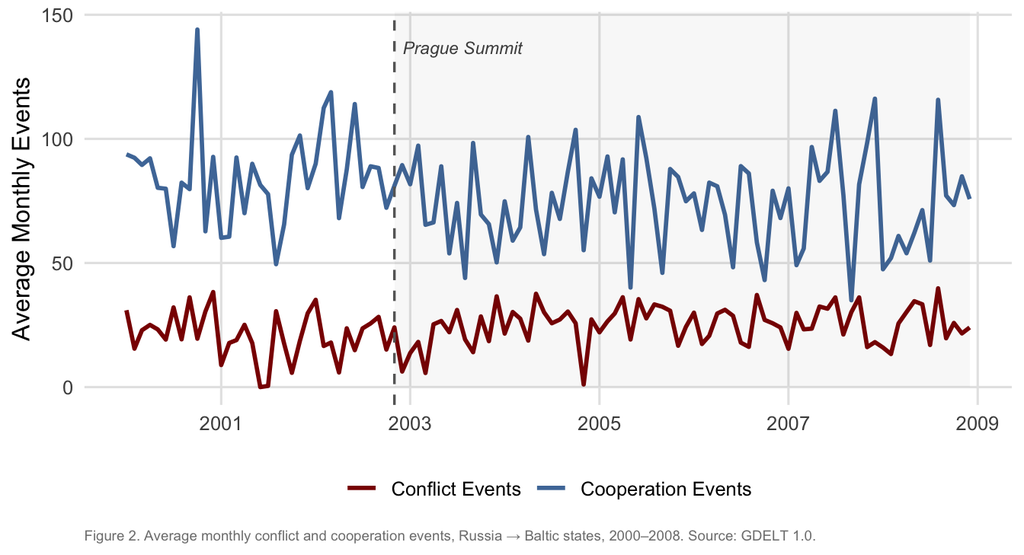

**Important**

Cooperation declines after 2002 while conflict stays flat — the share of hostile interactions rises, but not because Russia became more aggressive.

## Findings

### The Denominator Effect

The verbal conflict **share** rose, but *why*?

**What share increase could mean:**

↑ Russia more hostile (escalation)

*or*

↓ Russia less cooperative (disengagement)

**What the counts show:**

- Verbal conflict counts: **flat**
- Cooperation events: **declined**
- Total interactions: **fell**

→ Fewer total interactions = hostile events make up a larger *share* of what remained

## Findings

### The Denominator Effect Continued

**Note**

The appearance of escalation was actually **disengagement**. Russia withdrew from cooperative engagement rather than increasing hostile behavior.

## Findings

### Verbal Conflict Share Over Time

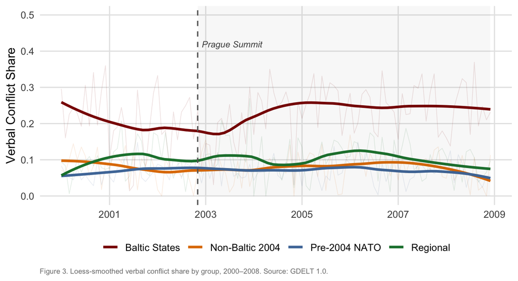

## Findings

### DiD Estimates

**Post-2002 (Prague Summit)**

- β = 0.027, SE = 0.015
- p = 0.085 *(marginal)*
- ~2.7 pp increase in verbal conflict share toward Baltics vs. control

→ Modest anticipatory signaling during accession window

**Post-2004 (Formal Accession)**

- β = 0.011, SE = 0.023
- p = 0.652 *(insignificant)*
- No detectable increase after membership formalized

## Findings

### DiD Estimates Continued

**Important**

Once the share increase is decomposed, the count of verbal conflict events did **not** meaningfully rise. The share result reflects falling cooperation, not rising hostility.

## Findings

### Event-Time Plot

[figure not shown]

## Findings

### Placebo Test

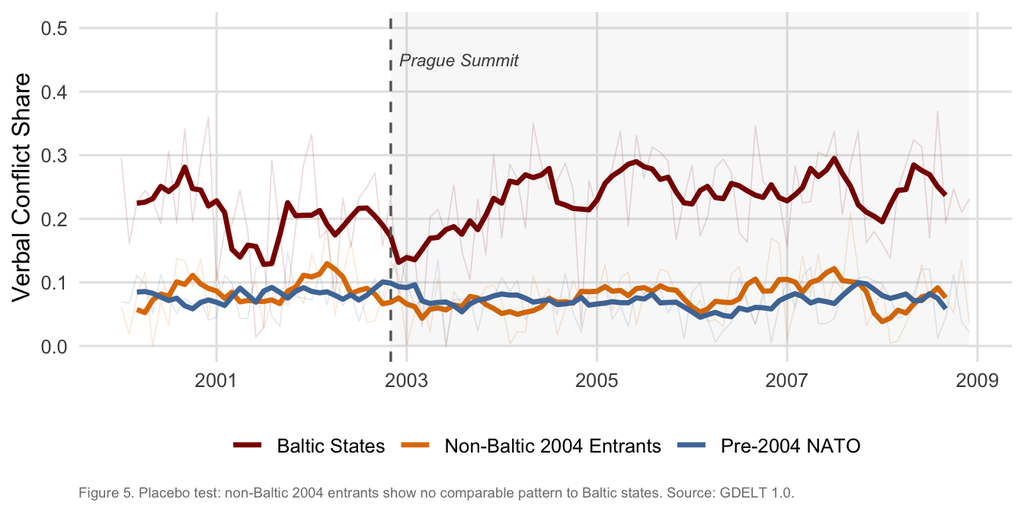

**Note**

Romania, Bulgaria, and Slovakia — same enlargement round, no comparable shift. The disengagement was **Baltic-specific**.

# Discussion & Conclusion

## Discussion

### Reinterpreting the Results

The share increase is a **compositional artifact**, not evidence of escalation:

- Conflict counts did **not** rise in absolute terms
- Cooperative interactions **fell** while conflict remained flat
- With fewer total interactions, hostility made up a larger share of what remained

## Discussion

### Reinterpreting the Results Continued

**Why did cooperation decline? Three possibilities:**

1. **Deliberate punishment** — Russia froze out the Baltics as low-cost retaliation below Article 5 threshold
2. **Natural wind-down** — once accession was decided, less to negotiate about
3. **Media shift** — GDELT captures journalist attention; reporters may have stopped covering routine cooperation stories

The data cannot distinguish between these and is an honest limitation.

## Discussion

### Broader Implications

**For realist theory:** Mearsheimer’s prediction of strong backlash finds only weak support. Russia did not dramatically escalate material conflict

**For signaling theory:** The modest rhetorical shift is consistent with Schelling’s logic, low-cost signaling below Article 5 threshold, but the mechanism was disengagement, not aggression

## Discussion

### Broader Implications Continued

**For the Baltic-specific argument:** Trenin and Cheskin’s emphasis on civilizational and identity factors appears more explanatory than institutional enlargement alone. Romania and Slovakia prove the point

## Conclusion

**What we found:**

- Russia **disengaged** from the Baltics, it did not escalate
- Cooperative interactions fell; conflict counts stayed flat
- The verbal conflict *share* rose as a mathematical consequence
- Effect was Baltic-specific, confirmed by placebo test

**Limitations:**

- Only 3 treated countries
- GDELT measures media, not diplomats
- Short pre-treatment window
- Single enlargement episode

## Conclusion Continued

**The Ukraine contrast:**

Russia disengaged from the Baltics (Article 5 protected), but later invaded Ukraine (no Article 5). The alliance guarantee may be the critical difference.

**Future research:**

- 2008 Bucharest Summit (Georgia, Ukraine)
- Diplomatic contact & trade flow data
- Long-term behavioral hardening

Thank you!

Email: alianasheriff@icloud.com